# R crash course for Computer Scientists

Arnaud Legrand

2022-10-06

## R is a high level functional and object oriented language

Keep in mind you should not consider R as a classical generic programming language. It is particularly well suited to data analysis involving statistics and probabilities.

### Object orientation

R provides a few built-in constants, variables, and functions to play with.

```r
pi
```

```
## [1] 3.141593
```

```r
letters
```

```
##  [1] "a" "b" "c" "d" "e" "f" "g" "h" "i" "j" "k" "l" "m" "n" "o" "p" "q" "r" "s"
## [20] "t" "u" "v" "w" "x" "y" "z"
```

```r
iris
```

```
##     Sepal.Length Sepal.Width Petal.Length Petal.Width    Species
## 1            5.1         3.5          1.4         0.2     setosa
## 2            4.9         3.0          1.4         0.2     setosa
## 3            4.7         3.2          1.3         0.2     setosa
## 4            4.6         3.1          1.5         0.2     setosa
## 5            5.0         3.6          1.4         0.2     setosa
## 6            5.4         3.9          1.7         0.4     setosa
## 7            4.6         3.4          1.4         0.3     setosa
## 8            5.0         3.4          1.5         0.2     setosa
## 9            4.4         2.9          1.4         0.2     setosa
## 10           4.9         3.1          1.5         0.1     setosa
## 11           5.4         3.7          1.5         0.2     setosa
## 12           4.8         3.4          1.6         0.2     setosa
## 13           4.8         3.0          1.4         0.1     setosa
## 14           4.3         3.0          1.1         0.1     setosa
```

[output cut: 136 more lines]

```r
mean
```

```
## function (x, ...)
## UseMethod("mean")
## <bytecode: 0x56471227f3e8>
## <environment: namespace:base>
```

Every variable is actually object so you can get information through `str` (structure) and `typeof`.

```r
str(pi); typeof(pi)
```

```
##  num 3.14
```

```
## [1] "double"
```

```r
str(letters); typeof(letters)
```

```
##  chr [1:26] "a" "b" "c" "d" "e" "f" "g" "h" "i" "j" "k" "l" "m" "n" "o" "p" ...
```

```
## [1] "character"
```

```r
str(mtcars); typeof(mtcars)
```

```
## 'data.frame':    32 obs. of  11 variables:
##  $ mpg : num  21 21 22.8 21.4 18.7 18.1 14.3 24.4 22.8 19.2 ...
##  $ cyl : num  6 6 4 6 8 6 8 4 4 6 ...
##  $ disp: num  160 160 108 258 360 ...
##  $ hp  : num  110 110 93 110 175 105 245 62 95 123 ...
##  $ drat: num  3.9 3.9 3.85 3.08 3.15 2.76 3.21 3.69 3.92 3.92 ...
##  $ wt  : num  2.62 2.88 2.32 3.21 3.44 ...
##  $ qsec: num  16.5 17 18.6 19.4 17 ...
##  $ vs  : num  0 0 1 1 0 1 0 1 1 1 ...
##  $ am  : num  1 1 1 0 0 0 0 0 0 0 ...
##  $ gear: num  4 4 4 3 3 3 3 4 4 4 ...
##  $ carb: num  4 4 1 1 2 1 4 2 2 4 ...
```

```
## [1] "list"
```

```r
str(mean); typeof(mean)
```

```
## function (x, ...)
```

```
## [1] "closure"
```

You can access the documentation with `?`

```r
?mean
```

### High level data structures

The types I use the more are vectors and data frames.

Let’s build a few ones.

```r
V = c(1,5,12) # c : Combine Values into a Vector or List
V
```

```
## [1]  1  5 12
```

```r
str(V)
```

```
##  num [1:3] 1 5 12
```

```r
V[1]  # Index starts at 1!
```

```
## [1] 1
```

```r
V[4] = 15 ; V
```

```
## [1]  1  5 12 15
```

```r
length(V)
```

```
## [1] 4
```

```r
V[0]  # Uh ?
```

```
## numeric(0)
```

```r
V[-1] # Oh... ok, this removes the first element
```

```
## [1]  5 12 15
```

```r
V[5]  # NA means "Not Available"
```

```
## [1] NA
```

```r
V = c(V,-5,1:4, seq.int(from=2, to = 10, by = 3), rep_len(NA,4), V);V
```

```
##  [1]  1  5 12 15 -5  1  2  3  4  2  5  8 NA NA NA NA  1  5 12 15
```

So you’d better be careful with indices. Array are dynamically resized but it comes with a cost so if you know the size in advance, you’d better initialize them.

Data frames are very handy and can be seen as a list of vectors which have all the same size.

```r
str(iris)
```

```
## 'data.frame':    150 obs. of  5 variables:
##  $ Sepal.Length: num  5.1 4.9 4.7 4.6 5 5.4 4.6 5 4.4 4.9 ...
##  $ Sepal.Width : num  3.5 3 3.2 3.1 3.6 3.9 3.4 3.4 2.9 3.1 ...
##  $ Petal.Length: num  1.4 1.4 1.3 1.5 1.4 1.7 1.4 1.5 1.4 1.5 ...
##  $ Petal.Width : num  0.2 0.2 0.2 0.2 0.2 0.4 0.3 0.2 0.2 0.1 ...
##  $ Species     : Factor w/ 3 levels "setosa","versicolor",..: 1 1 1 1 1 1 1 1 1 1 ...
```

```r
dim(iris)
```

```
## [1] 150   5
```

```r
iris[3,1]
```

```
## [1] 4.7
```

```r
iris[3,"Sepal.Length"]
```

```
## [1] 4.7
```

```r
iris$Sepal.Length
```

```
##   [1] 5.1 4.9 4.7 4.6 5.0 5.4 4.6 5.0 4.4 4.9 5.4 4.8 4.8 4.3 5.8 5.7 5.4 5.1
##  [19] 5.7 5.1 5.4 5.1 4.6 5.1 4.8 5.0 5.0 5.2 5.2 4.7 4.8 5.4 5.2 5.5 4.9 5.0
##  [37] 5.5 4.9 4.4 5.1 5.0 4.5 4.4 5.0 5.1 4.8 5.1 4.6 5.3 5.0 7.0 6.4 6.9 5.5
##  [55] 6.5 5.7 6.3 4.9 6.6 5.2 5.0 5.9 6.0 6.1 5.6 6.7 5.6 5.8 6.2 5.6 5.9 6.1
##  [73] 6.3 6.1 6.4 6.6 6.8 6.7 6.0 5.7 5.5 5.5 5.8 6.0 5.4 6.0 6.7 6.3 5.6 5.5
##  [91] 5.5 6.1 5.8 5.0 5.6 5.7 5.7 6.2 5.1 5.7 6.3 5.8 7.1 6.3 6.5 7.6 4.9 7.3
## [109] 6.7 7.2 6.5 6.4 6.8 5.7 5.8 6.4 6.5 7.7 7.7 6.0 6.9 5.6 7.7 6.3 6.7 7.2
## [127] 6.2 6.1 6.4 7.2 7.4 7.9 6.4 6.3 6.1 7.7 6.3 6.4 6.0 6.9 6.7 6.9 5.8 6.8
## [145] 6.7 6.7 6.3 6.5 6.2 5.9
```

```r
iris$Sepal.Length[3] # much more convenient
```

```
## [1] 4.7
```

```r
df = data.frame(Col1 = V, Col2 = "Hello", Col3 = 1:2, Col4 = as.factor(c("A", "B", "C","D")))
str(df)
```

```
## 'data.frame':    20 obs. of  4 variables:
##  $ Col1: num  1 5 12 15 -5 1 2 3 4 2 ...
##  $ Col2: chr  "Hello" "Hello" "Hello" "Hello" ...
##  $ Col3: int  1 2 1 2 1 2 1 2 1 2 ...
##  $ Col4: Factor w/ 4 levels "A","B","C","D": 1 2 3 4 1 2 3 4 1 2 ...
```

```r
df
```

```
##    Col1  Col2 Col3 Col4
## 1     1 Hello    1    A
## 2     5 Hello    2    B
## 3    12 Hello    1    C
## 4    15 Hello    2    D
## 5    -5 Hello    1    A
## 6     1 Hello    2    B
## 7     2 Hello    1    C
## 8     3 Hello    2    D
## 9     4 Hello    1    A
## 10    2 Hello    2    B
## 11    5 Hello    1    C
## 12    8 Hello    2    D
## 13   NA Hello    1    A
## 14   NA Hello    2    B
## 15   NA Hello    1    C
## 16   NA Hello    2    D
## 17    1 Hello    1    A
## 18    5 Hello    2    B
## 19   12 Hello    1    C
## 20   15 Hello    2    D
```

You can also combine data frames together with `rbind` and `cbind`:

```r
nrow(df)
```

```
## [1] 20
```

```r
df = rbind(df,df)
nrow(df)
```

```
## [1] 40
```

But in practice, you often read dataframes from existing databases or datafiles, e.g., with `read.csv`.

```r
df = read.csv("https://www.stats.govt.nz/assets/Uploads/Consumers-price-index/Consumers-price-index-September-2022-quarter/Download-data/consumers-price-index-september-2022-quarter-seasonally-adjusted.csv", header = T, sep=",")
str(df)
```

```
## 'data.frame':    11131 obs. of  8 variables:
##  $ Series_reference: chr  "CPIQ.SE9S01" "CPIQ.SE9S01" "CPIQ.SE9S01" "CPIQ.SE9S01" ...
##  $ Period          : num  2006 2006 2006 2007 2007 ...
##  $ Data_value      : num  762 771 780 788 794 796 814 828 849 871 ...
##  $ STATUS          : chr  "REVISED" "REVISED" "REVISED" "REVISED" ...
##  $ UNITS           : chr  "Index" "Index" "Index" "Index" ...
##  $ Subject         : chr  "CPI" "CPI" "CPI" "CPI" ...
##  $ Group           : chr  "CPI Level 1 Groups for New Zealand, Seasonally adjusted" "CPI Level 1 Groups for New Zealand, Seasonally adjusted" "CPI Level 1 Groups for New Zealand, Seasonally adjusted" "CPI Level 1 Groups for New Zealand, Seasonally adjusted" ...
##  $ Series_title_1  : chr  "Seasonally adjusted" "Seasonally adjusted" "Seasonally adjusted" "Seasonally adjusted" ...
```

```r
head(df)
```

```
##   Series_reference  Period Data_value  STATUS UNITS Subject
## 1      CPIQ.SE9S01 2006.06        762 REVISED Index     CPI
## 2      CPIQ.SE9S01 2006.09        771 REVISED Index     CPI
## 3      CPIQ.SE9S01 2006.12        780 REVISED Index     CPI
## 4      CPIQ.SE9S01 2007.03        788 REVISED Index     CPI
## 5      CPIQ.SE9S01 2007.06        794 REVISED Index     CPI
## 6      CPIQ.SE9S01 2007.09        796 REVISED Index     CPI
##                                                     Group      Series_title_1
## 1 CPI Level 1 Groups for New Zealand, Seasonally adjusted Seasonally adjusted
## 2 CPI Level 1 Groups for New Zealand, Seasonally adjusted Seasonally adjusted
## 3 CPI Level 1 Groups for New Zealand, Seasonally adjusted Seasonally adjusted
## 4 CPI Level 1 Groups for New Zealand, Seasonally adjusted Seasonally adjusted
## 5 CPI Level 1 Groups for New Zealand, Seasonally adjusted Seasonally adjusted
## 6 CPI Level 1 Groups for New Zealand, Seasonally adjusted Seasonally adjusted
```

### Vectorization

Obviously, R provides classical imperative control structures like branching, `for` and `while` loops but there is generally a better style. So avoid them as much as possible.

```r
for(i in 1:length(V)) {
  print(paste0("V[",i,"]^2 = ",V[i]^2))
}
```

```
## [1] "V[1]^2 = 1"
## [1] "V[2]^2 = 25"
## [1] "V[3]^2 = 144"
## [1] "V[4]^2 = 225"
## [1] "V[5]^2 = 25"
## [1] "V[6]^2 = 1"
## [1] "V[7]^2 = 4"
## [1] "V[8]^2 = 9"
## [1] "V[9]^2 = 16"
## [1] "V[10]^2 = 4"
## [1] "V[11]^2 = 25"
## [1] "V[12]^2 = 64"
## [1] "V[13]^2 = NA"
## [1] "V[14]^2 = NA"
## [1] "V[15]^2 = NA"
## [1] "V[16]^2 = NA"
## [1] "V[17]^2 = 1"
## [1] "V[18]^2 = 25"
## [1] "V[19]^2 = 144"
## [1] "V[20]^2 = 225"
```

Note that you may wonder yourself how tests react to `NA` ?…

Anyway, R is a high level language which provides *vectorization*, i.e. most built-in operators and functions handle seamlessly vectors.

```r
V = 1:5
V+12
```

```
## [1] 13 14 15 16 17
```

```r
V = log(V^3) + 3*sin(V); V
```

```
## [1] 2.524413 4.807334 3.719197 1.888476 1.951541
```

```r
V <= 3
```

```
## [1]  TRUE FALSE FALSE  TRUE  TRUE
```

Even subsetting is vectorized

```r
V[c(5,1:2)]
```

```
## [1] 1.951541 2.524413 4.807334
```

```r
V[V <= 2]
```

```
## [1] 1.888476 1.951541
```

This is particularly convenient with dataframes as you can easily extract information “à la SQL”.

```r
d = iris[iris$Sepal.Length <=mean(iris$Sepal.Length) &
         iris$Petal.Length <=mean(iris$Petal.Length) ,]
d
```

```
##    Sepal.Length Sepal.Width Petal.Length Petal.Width    Species
## 1           5.1         3.5          1.4         0.2     setosa
## 2           4.9         3.0          1.4         0.2     setosa
## 3           4.7         3.2          1.3         0.2     setosa
## 4           4.6         3.1          1.5         0.2     setosa
## 5           5.0         3.6          1.4         0.2     setosa
## 6           5.4         3.9          1.7         0.4     setosa
## 7           4.6         3.4          1.4         0.3     setosa
## 8           5.0         3.4          1.5         0.2     setosa
## 9           4.4         2.9          1.4         0.2     setosa
## 10          4.9         3.1          1.5         0.1     setosa
## 11          5.4         3.7          1.5         0.2     setosa
## 12          4.8         3.4          1.6         0.2     setosa
## 13          4.8         3.0          1.4         0.1     setosa
## 14          4.3         3.0          1.1         0.1     setosa
```

[output cut: 43 more lines]

```r
d$Weird = log(d$Sepal.Length)*sin(d$Sepal.Width)
summary(d)
```

```
##   Sepal.Length    Sepal.Width     Petal.Length    Petal.Width
##  Min.   :4.300   Min.   :2.000   Min.   :1.000   Min.   :0.1000
##  1st Qu.:4.800   1st Qu.:3.000   1st Qu.:1.400   1st Qu.:0.2000
##  Median :5.000   Median :3.400   Median :1.500   Median :0.2000
##  Mean   :5.037   Mean   :3.307   Mean   :1.702   Mean   :0.3456
##  3rd Qu.:5.200   3rd Qu.:3.600   3rd Qu.:1.600   3rd Qu.:0.4000
##  Max.   :5.800   Max.   :4.400   Max.   :3.700   Max.   :1.3000
##        Species       Weird
##  setosa    :50   Min.   :-1.6562
##  versicolor: 7   1st Qu.:-0.7033
##  virginica : 0   Median :-0.4008
##                  Mean   :-0.2602
##                  3rd Qu.: 0.2058
##                  Max.   : 1.4635
```

So R being a functional language, it provides many simple functions, which, once well combined are very powerful. Check for example `sum`, `cumsum`, `ifthen`, …

### Random number generation

R embeds every random generator you can dream of. The naming convention is as follows for a law `law`: - `rlaw`: random number generator for `law` - `dlaw`: density function ($\mathbb{R}\to\mathbb{R}^+$) - `plaw`: cumulative density function ($\mathbb{R}\to[0,1]$) - `qlaw`: reciprocal of the cdf, i.e., quantile ($[0,1]\to\mathbb{R}$) Classical laws are `unif`, `norm`, `exp`, `cauchy`, `beta`, …

```r
rnorm(n = 10, mean = 2, sd = 1)
```

```
##  [1]  2.3218859  1.2620736  1.8303027 -0.2097472  3.4779876  0.4682419
##  [7]  2.1761946  2.6668669  1.5530110  1.5949745
```

For custom discrete distributions, you may want to use the `sample` function.

### Statistics and plots

Obviously, you have access to `mean`, `min`, `max`, `median`, `var`, `sd`, `summary` (which properly handle `NA`s) but also tests `chisq.test`, `wilcox.test`, etc. The default choices are generally good choices from a statistician point of view and formulas are correct (e.g., unbiased estimators).

Default plots are not very nice but quite effective.

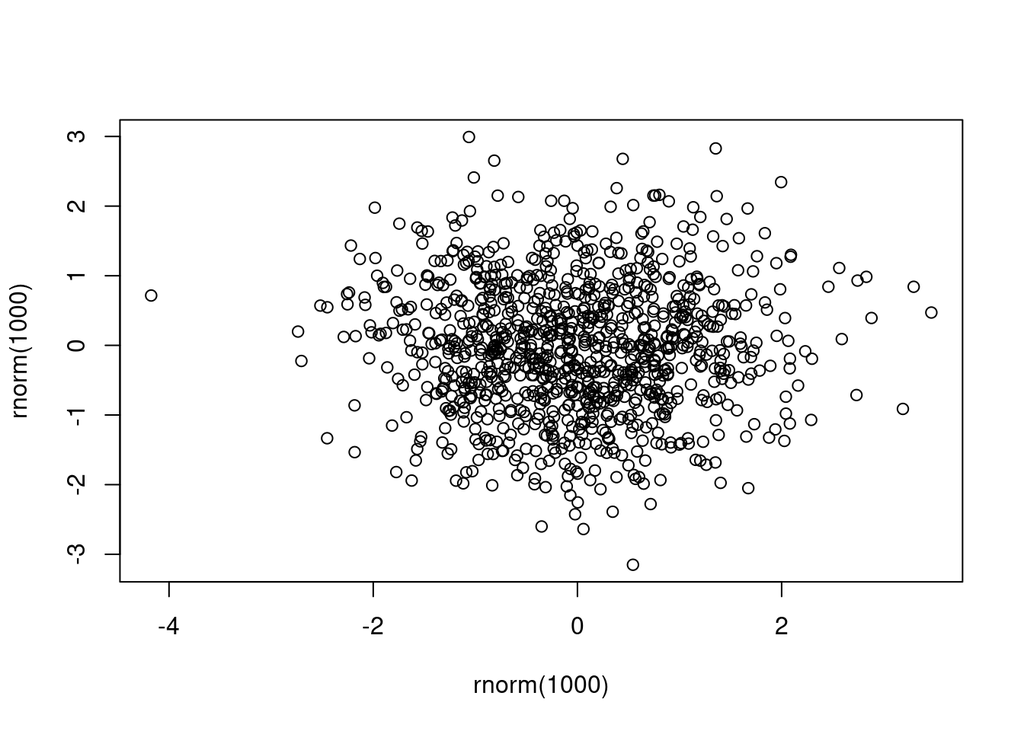

```r
plot(rnorm(1000), rnorm(1000))
```

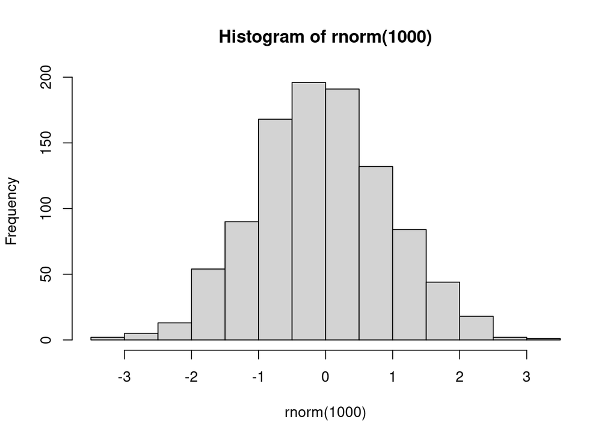

```r
hist(rnorm(1000))
```

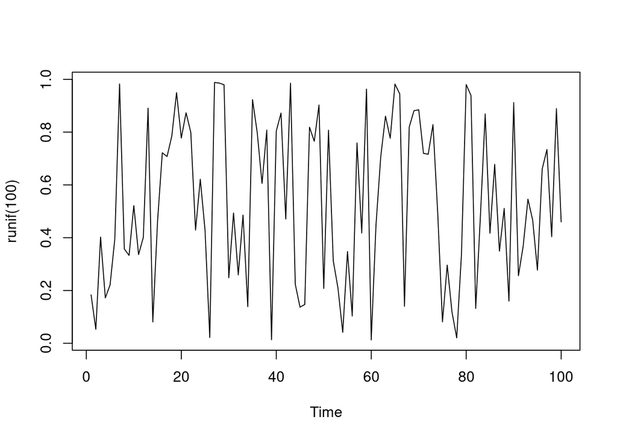

```r
plot.ts(runif(100))
```

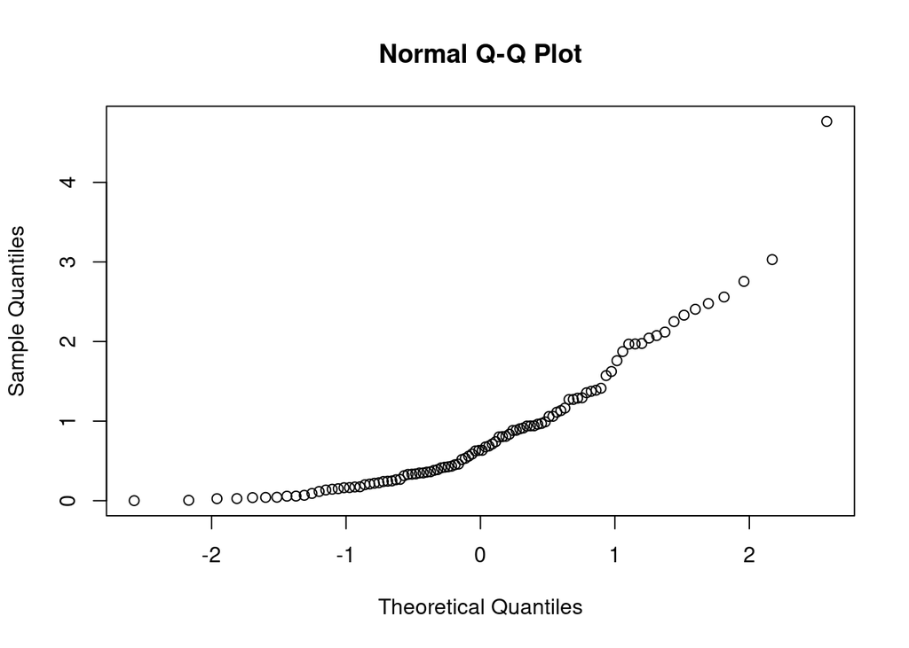

```r
x = rexp(100)
qqnorm(x)
```

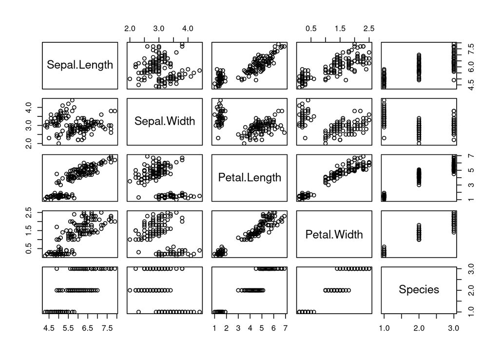

```r
plot(iris)
```

### Function

As explained earlier, there are many built-in functions but you may want to write your own. In R, functions have named arguments with possible default value (so it acts as optional arguments).

```r
mynorm2 = function(n = 10, Mean = 2, SD = 1.2, power = 2) { # Uggly variable names. Do not do this!
  return(rnorm(n = n, mean = Mean, sd = SD)^power)
}
mynorm2() # What does this do ?
```

```
##  [1]  0.6151725  1.0631962  5.0187314  0.5586926  5.9965693  0.0355165
##  [7] 10.1366662  0.1345323  4.4921970  4.1471565
```

```r
mynorm2(5,-1,1.1,10) # Err ?
```

```
## [1] 8.666163e-06 1.796152e+00 1.498687e-05 2.583253e+00 7.851067e-28
```

```r
mynorm2(Mean = 2 , power = 1.4, SD = 1.4) # Better
```

```
##  [1] 1.9847818 0.4467111 3.4677991 3.8036897 3.4352086 0.3156170 5.9349400
##  [8] 3.2387801 0.1531941 6.8468332
```

### R can be quite surprising

Lexical scoping. There are several assignment operators. AFAIK `=` and `<-` (or `->`) are equivalent but `<<-` could be what you’re looking for if you need side effects in recursive functions… :)

```r
x <- 1
f = function() {
  x <- 5 # or 5 -> x
  print(x)
}
f()
```

```
## [1] 5
```

```r
print(x)
```

```
## [1] 1
```

```r
g = function() {
  x <<- 5
  print(x)
}
g()
```

```
## [1] 5
```

```r
print(x)
```

```
## [1] 5
```

Here is an other interesting feature from a semantic aspect. How the hell does R know the (outer) variable names inside the function ? :)

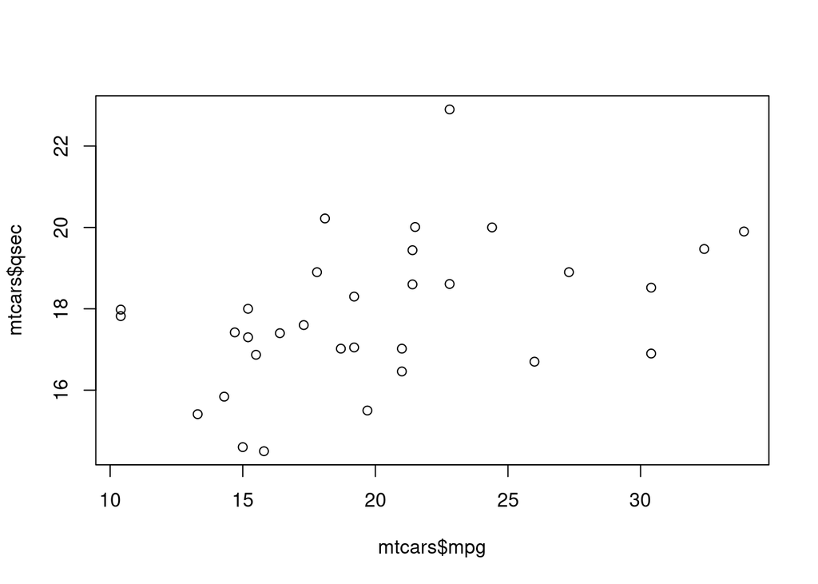

```r
plot(mtcars$mpg,mtcars$qsec)
```

## The tidyverse

### Dplyr

The R function names and API is not very consistent nor convenient when working with data frames. This is quite error prone.

```r
mtcars[mtcars$cyl==6 & mtcars$hp >120,]
```

```
##               mpg cyl  disp  hp drat   wt qsec vs am gear carb
## Merc 280     19.2   6 167.6 123 3.92 3.44 18.3  1  0    4    4
## Merc 280C    17.8   6 167.6 123 3.92 3.44 18.9  1  0    4    4
## Ferrari Dino 19.7   6 145.0 175 3.62 2.77 15.5  0  1    5    6
```

```r
library(dplyr)
mtcars %>% filter(cyl==6 & hp >120)
```

```
##               mpg cyl  disp  hp drat   wt qsec vs am gear carb
## Merc 280     19.2   6 167.6 123 3.92 3.44 18.3  1  0    4    4
## Merc 280C    17.8   6 167.6 123 3.92 3.44 18.9  1  0    4    4
## Ferrari Dino 19.7   6 145.0 175 3.62 2.77 15.5  0  1    5    6
```

```r
mtcars %>% filter(cyl==6 & hp >120) %>% select(mpg, cyl, hp, qsec)
```

```
##               mpg cyl  hp qsec
## Merc 280     19.2   6 123 18.3
## Merc 280C    17.8   6 123 18.9
## Ferrari Dino 19.7   6 175 15.5
```

```r
mtcars %>% group_by(cyl,vs) %>% summarise(qsec_mean=mean(qsec),
                                       qsec_sd=sd(qsec),
                                       num = n()) -> df
```

Efficient, expressive, avoids side effects. Can be used to create splitted models. See R4DS for more.

### Ggplot

R plots can be surprising, uggly, and have funky documentations with obscure arguments.

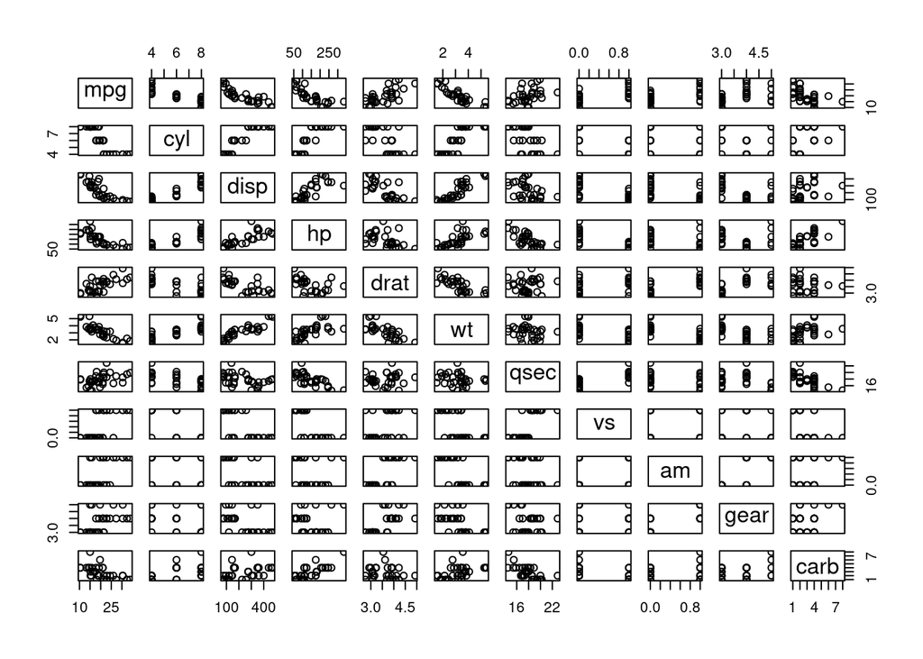

```r
plot(mtcars)
```

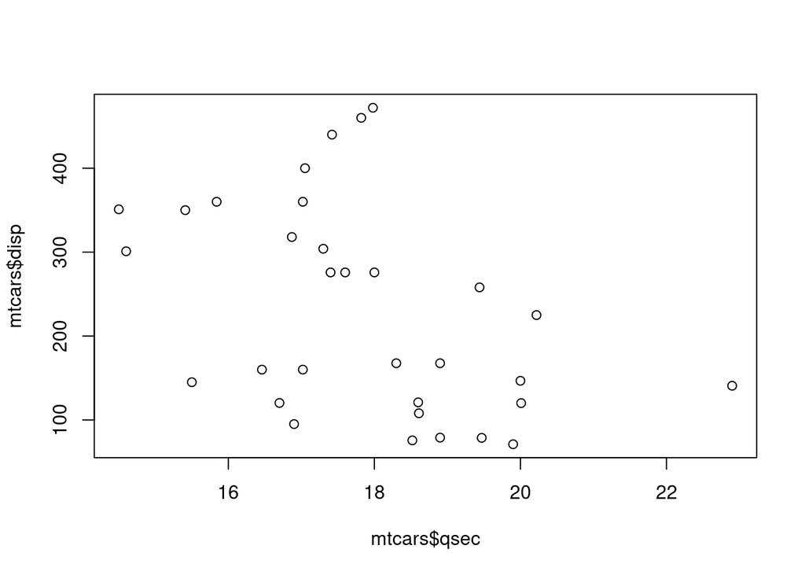

```r
plot(mtcars$qsec,mtcars$disp)
```

But ggplot2 empowers you with lego blocks and a high level grammar of graphics

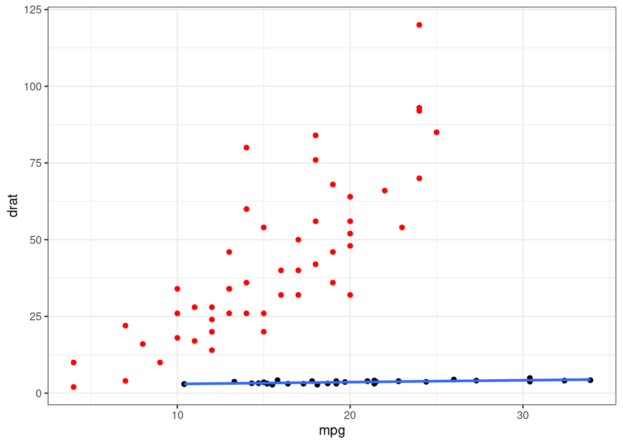

```r
library(ggplot2)
ggplot(mtcars, aes(x = mpg, y = drat )) + geom_point() +
  geom_point(data = cars, aes(x = speed, y=dist), color = "red") +
  theme_bw() + geom_smooth(method = "lm")
```